# TURO Investment Tool

## DATA ANALYTICS FINALLE

```python
#As a result of EDA stage we would like to demonstrate to owners their earnings:
df['Earning_nofee'] = (df['Ut_R']*df['Price per day']*30)*0.75
```

```python
#Final report for
df.groupby(['cluster_label'])['State', 'City', 'Make', 'Model','Year','Ut_R', 'Price per day', 'Earning_nofee' ].apply(lambda x: x.nlargest(3, columns=['Earning_nofee']))
```

| cluster_label |  | State | City | Make | Model | Year | Ut_R | Price per day | Earning_nofee |
| --- | --- | --- | --- | --- | --- | --- | --- | --- | --- |
| 0 | 2750 | WA | Gig Harbor | jeep | gladiator | 2020.0 | 0.499517 | 85.00 | 955.326087 |
|  | 2653 | WA | Newcastle | land rover | range rover sport | 2018.0 | 0.229101 | 180.00 | 927.857143 |
|  | 1588 | MT | Bozeman | lexus | rx 350 | 2011.0 | 0.403190 | 95.00 | 861.818496 |
| 1 | 937 | GA | Kennasaw | chevrolet | suburban | 2016.0 | 0.250000 | 180.00 | 1012.500000 |
|  | 3297 | TX | Austin | land rover | range rover sport | 2020.0 | 0.253175 | 169.00 | 962.696429 |
|  | 206 | GA | Norcross | ford | escape | 2017.0 | 0.774713 | 54.00 | 941.275862 |
| 2 | 3908 | CA | Los Angeles | mercedes-benz | g-class | 2020.0 | 0.250000 | 439.00 | 2469.375000 |
|  | 2338 | CA | Los Angeles | bentley | bentayga | 2018.0 | 0.215162 | 449.00 | 2173.670569 |
|  | 1898 | CA | Los Angeles | lamborghini | huracan | 2016.0 | 0.133838 | 649.00 | 1954.375000 |
| 3 | 2689 | HI | Honolulu | lexus | rx 350 | 2018.0 | 0.613793 | 120.00 | 1657.241379 |
|  | 1908 | HI | Kapolei | tesla | model x | 2018.0 | 0.395833 | 149.00 | 1327.031250 |
|  | 1771 | HI | Kihei | toyota | 4runner | 2016.0 | 0.530105 | 108.00 | 1288.155080 |
| 4 | 193 | FL | Miami Beach | land rover | range rover sport | 2014.0 | 0.580247 | 150.00 | 1958.333333 |
|  | 3287 | FL | Weston | bmw | x7 | 2020.0 | 0.333333 | 215.28 | 1614.600000 |
|  | 2038 | FL | Miami Beach | porsche | panamera | 2012.0 | 0.402778 | 159.00 | 1440.937500 |
| 5 | 1626 | NJ | Jersey City | porsche | cayenne | 2019.0 | 0.318519 | 225.00 | 1612.500000 |
|  | 446 | MD | Lanham | tesla | model x | 2018.0 | 0.467570 | 140.00 | 1472.844828 |
|  | 3179 | MA | Cambridge | maserati | levante | 2018.0 | 0.517241 | 109.00 | 1268.534483 |
| 6 | 704 | CA | San Jose | bentley | continental gt | 2007.0 | 0.349206 | 325.00 | 2553.571429 |
|  | 2214 | CA | Oakland | tesla | model x | 2017.0 | 0.595238 | 130.00 | 1741.071429 |
|  | 2590 | CA | Oakland | audi | r8 | 2011.0 | 0.176190 | 399.00 | 1581.750000 |
| 7 | 1861 | CO | Denver | bmw | 2 series | 2016.0 | 0.378333 | 167.00 | 1421.587500 |
|  | 177 | CO | Aspen | tesla | model x | 2016.0 | 0.309790 | 199.00 | 1387.085664 |
|  | 3026 | CO | Aurora | cadillac | escalade esv | 2018.0 | 0.702335 | 79.00 | 1248.400578 |

This chart is serving for all car owners as an illustration of potential inсome from renting out your car. It is separated by area through the USA. With it they can take an investment decisions, especially about ROI.

## 3. Natural Language Processing

In this part of EDA we would like to review the "Description" fiels in our dataset and to find any insights that help owner to increase their utilization rate (words, 2 grams) For this purpose we need to transform the text to words or vectors and then add it into the variable dataset.

1. Simply check correlation between text length and target variable.
2. Create additional variables from text (dummies) to see if there is a correlation between certain words and outcome

### Length of the String

```python
#first of all let's measure the length of the string and will see if this variable can affect the utilization
df['Description_len']= df['Description'].apply(len)
```

```
[Text(0.5, 1.0, 'Description length to Utilization rate')]
```

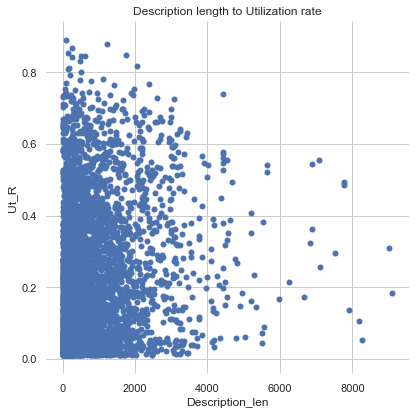

```python
import seaborn as sns
import matplotlib.pyplot as plt
sns.set(style="whitegrid")


# Draw a scatter plot while assigning point colors and sizes to different
# variables in the dataset
f, ax = plt.subplots(figsize=(6.5, 6.5))
sns.despine(f, left=True, bottom=True)
clarity_ranking = ["I1", "SI2", "SI1", "VS2", "VS1", "VVS2", "VVS1", "IF"]
sns.scatterplot(x="Description_len", y="Ut_R",
                palette="ch:r=-.2,d=.3_r",
                hue_order=clarity_ranking,
                sizes=(1, 8), linewidth=0,
                data=df, ax=ax).set(title = "Description length to Utilization rate")
```

### Text preprocessing

```python
df.Description
```

```
0       This is a FANTASTIC 2018 Jeep Cherokee with fu...
1       Reliable, inexpensive and safe car  Safe - Fro...
2       - Excellent gas mileage! Saves about $10 for e...
3       Please note that while I can sometimes accommo...
4       Handsome mid-size SUV with spacious interior. ...
                              ...
3907    2019 Jeep Wrangler    3.45 Rear Axle Ratio4-Wh...
3908    If you love adventure but still want all the c...
3909    *** COVID-19: We use sanitizing wipes before a...
3910    This car is conveniently located approx 10 mil...
3911    *** COVID-19: We use sanitizing wipes before a...
Name: Description, Length: 3912, dtype: object
```

```python
#Removing the html strips
def strip_html(text):
    soup = BeautifulSoup(text, "html.parser")
    return soup.get_text()

#Removing the square brackets
def remove_between_square_brackets(text):
    return re.sub('\[[^]]*\]', '', text)

#Removing the noisy text
def denoise_text(text):
    text = strip_html(text)
    text = remove_between_square_brackets(text)
    return text

#Removing special characters
def remove_special_characters(text, remove_digits=True):
    pattern=r'[^a-zA-z0-9\s]'
    text=re.sub(pattern,'',text)
    return text

#Removing string punctuation
PUNCT_TO_REMOVE = string.punctuation
def remove_punctuation(text):
    """custom function to remove the punctuation"""
    return text.translate(str.maketrans('', '', PUNCT_TO_REMOVE))

#Removing emoji
def remove_emoji(string):
    emoji_pattern = re.compile("["
                           u"\U0001F600-\U0001F64F"  # emoticons
                           u"\U0001F300-\U0001F5FF"  # symbols & pictographs
                           u"\U0001F680-\U0001F6FF"  # transport & map symbols
                           u"\U0001F1E0-\U0001F1FF"  # flags (iOS)
                           u"\U00002702-\U000027B0"
                           u"\U000024C2-\U0001F251"
                           "]+", flags=re.UNICODE)
    return emoji_pattern.sub(r'', string)

#Remove _tags
def remove_html(text):
    html_pattern = re.compile('<.*?>')
    return html_pattern.sub(r'', text)

#Convert_ numbers
def convert_numbers(text):
    tokens = word_tokenize(str(text))
    new_text = ""
    for w in tokens:
        try:
            w = num2words(int(w))
        except:
            a = 0
        new_text = new_text + " " + w
    new_text = np.char.replace(new_text, "-", " ")
    return new_text

#Convert_ punctuations
def remove_punctuation(data):
    symbols = "!\"#$%&()*+-./:;<=>?@[\]^_`{|}~\n"
    for i in range(len(symbols)):
        data = np.char.replace(data, symbols[i], ' ')
        data = np.char.replace(data, "  ", " ")
    data = np.char.replace(data, ',', '')
    return data

#Lemmatise the words
#We will use Lemmatization because we would like to keep all the words from english language in their original form, not just the stem
from nltk.stem import WordNetLemmatizer
lemmatizer = WordNetLemmatizer()
def lemmatize_words(text):
    return " ".join([lemmatizer.lemmatize(word) for word in text.split()])
```

```python
#Apply functions on the description column
df['Description_cl'] = df.Description.str.lower()
df['Description_cl']=df['Description_cl'].apply(lambda text: strip_html(text))
df['Description_cl']=df['Description_cl'].apply(lambda text: remove_html(text))
df['Description_cl']=df['Description_cl'].apply(lambda text: remove_special_characters(text))
df['Description_cl']=df['Description_cl'].apply(lambda text: remove_punctuation(text))
df['Description_cl']=df['Description_cl'].apply(lambda text: remove_emoji(text))
df["Description_cl"] = df["Description_cl"].apply(lambda text: lemmatize_words(text))
```

```python
df['Description_cl']
```

```
0       this is a fantastic 2018 jeep cherokee with fu...
1       reliable inexpensive and safe car safe front a...
2       excellent gas mileage save about 10 for every ...
3       please note that while i can sometimes accommo...
4       handsome midsize suv with spacious interior fi...
                              ...
3907    2019 jeep wrangler 345 rear axle ratio4wheel d...
3908    if you love adventure but still want all the c...
3909    covid19 we use sanitizing wipe before and afte...
3910    this car is conveniently located approx 10 mil...
3911    covid19 we use sanitizing wipe before and afte...
Name: Description_cl, Length: 3912, dtype: object
```

Work on Stopwords

```python
#Tokenization of text
tokenizer=ToktokTokenizer()

#let's checlk stopwords and add some others to them
stopwords = nltk.corpus.stopwords.words('english')
make_stop = df['Make'].unique().tolist()
model_stop = df['Model'].unique().tolist()
new_words='car','vehicle','trip', 'turo', 'drive', 'u', 'ha'
for i in new_words:
    stopwords.append(i)
for i in make_stop:
    stopwords.append(i)
for i in model_stop:
    stopwords.append(i)
print(stopwords)
```

```
['i', 'me', 'my', 'myself', 'we', 'our', 'ours', 'ourselves', 'you', "you're", "you've", "you'll", "you'd", 'your', 'yours', 'yourself', 'yourselves', 'he', 'him', 'his', 'himself', 'she', "she's", 'her', 'hers', 'herself', 'it', "it's", 'its', 'itself', 'they', 'them', 'their', 'theirs', 'themselve…
```

```python
def remove_stopwords(data):
    stop_words = stopwords
    words = word_tokenize(str(data))
    new_text = ""
    for w in words:
        if w not in stop_words and len(w) > 1:
            new_text = new_text + " " + w
    return new_text
df['Description_cl']=df['Description_cl'].apply(lambda data:remove_stopwords(data))
```

```python
df['Description_cl']
```

```
0        fantastic 2018 fully loaded feature sleek eno...
1        reliable inexpensive safe safe front sideairb...
2        excellent gas mileage save 10 every day used ...
3        please note sometimes accommodate last minute...
4        handsome midsize suv spacious interior people...
                              ...
3907     2019 345 rear axle ratio4wheel disc brakes8 s...
3908     love adventure still want comfort luxury look...
3909     covid19 use sanitizing wipe rental major touc...
3910     conveniently located approx 10 mile se ohare ...
3911     covid19 use sanitizing wipe rental major touc...
Name: Description_cl, Length: 3912, dtype: object
```

```python
#Let's see the most common words and remove non-significant
from collections import Counter
cnt = Counter()
for text in df["Description_cl"].values:
    for word in text.split():
        cnt[word] += 1

cnt.most_common(30)
```

```
[('please', 3384),
 ('seat', 3028),
 ('fee', 1957),
 ('gas', 1698),
 ('airport', 1688),
 ('free', 1658),
 ('rental', 1623),
 ('great', 1514),
 ('time', 1438),
 ('get', 1389),
 ('mile', 1305),
 ('clean', 1262),
 ('charge', 1235),
 ('wheel', 1214),
 ('return', 1174),
 ('new', 1169),
 ('power', 1164),
 ('delivery', 1150),
 ('need', 1114),
 ('parking', 1095),
 ('system', 1086),
 ('available', 1077),
 ('smoking', 1074),
 ('rear', 1043),
 ('take', 1042),
 ('interior', 1039),
 ('front', 1029),
 ('control', 1008),
 ('back', 1006),
 ('leather', 984)]
```

## WORDCLOUDS

Let's see the wordclouds for our cleaned variable

```python
Text = df['Description_cl'].values
```

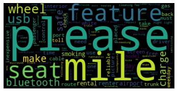

```python
wordcloud = WordCloud().generate(str(Text))

plt.imshow(wordcloud, interpolation="bilinear")
plt.axis("off")
plt.show()
```

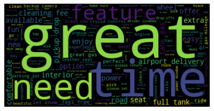

```python
#word cloud for cars that occupied more than 40% per month
df_TOP = df[(df['Ut_R']>0.4)]
Text1 = df_TOP['Description_cl'].values
wordcloud = WordCloud().generate(str(Text1))

plt.imshow(wordcloud, interpolation="bilinear")
plt.axis("off")
plt.show()
```

here we see more words with Great, Need, Time, Feature, Full tank, Airpot Delivery, Power, Fun

### Description Text Generation

With the wide abilities of the text generation we would like to create descriptions from the listings that has higher utilisation rate. We're going to use Markov's method

```python
nlp = spacy.load('en')
```

```python
persuasion_generator = markovify.Text(df_TOP['Description'], state_size = 3)
```

```python
# three randomly generated sentences
for i in range(3):
    print(persuasion_generator.make_sentence())

# three randomly-generated sentences of no more than 100 characters
for i in range(3):
    print(persuasion_generator.make_short_sentence(100))
```

```
None
You may use EZpass tag in the car when you pick it up.
Additional drivers can be requested free of charge provided they are approved by Turo.
Just go to the front desk and they will take you to the rent a car center at the airport.
Send us your flight information and we will remote unlock it for you.
We want you to enjoy your trip in the summer!
```

```python
class POSifiedText(markovify.Text):

    def word_split(self, sentence):
        return ["::".join((word.orth_, word.pos_)) for word in nlp(sentence)]

    def word_join(self, words):
        sentence = " ".join(word.split("::")[0] for word in words)
        return sentence
```

```python
persuasion_generator = POSifiedText(df_TOP['Description'], state_size = 3)
```

```python
# Print five randomly-generated sentences
for i in range(5):
    print(persuasion_generator.make_sentence())

# Print three randomly-generated sentences of no more than 100 characters
for i in range(3):
    print(persuasion_generator.make_short_sentence(100))
```

```
We 'll send you exact pick up and drop off is Doraville MARTA .
At around 30mpg , this is the same thing that would happen with other rental companies .
Please wash and vacuum at end of the rental .
A / C blows ICE cold   Out of town travelers only .
Check them out if you have trouble , I will meet up with you to enhance your visit .
This is an awesome mid - size SUV with lots of leg room and luggage space .
2013 Hyundai Sonata   Please notice that most of our cars are available for a small fee .
4 door sedan with a lot of time cleaning and disinfecting the inside of the vehicle ’s interior .
```

### TOKENISE

```python
df["Description_tokens"] = df["Description_cl"].apply(nltk.word_tokenize)
```

#### Bag of Words

We will start with the easiest NLP tool - bag of words. This tool allows us to count the is a representation of text that describes the occurrence of words within a document.

let's reindex our dataframe so we can work later with the bow array

```python
df = df.reset_index(drop=True)
```

```python
#let's creat a bag of words. We're going to use only "words" and now will check 1 gran
vectorizer = CountVectorizer(analyzer='word', token_pattern = r'\b[^\d\W]+\b')
X = vectorizer.fit_transform(df['Description_tokens'])
bow_df = pd.DataFrame(X.toarray(), columns=vectorizer.get_feature_names())
df_bof = pd.concat([bow_df, df[["Description_tokens", "Ut_R"]]], axis=1)
```

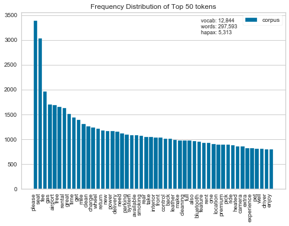

```python
#this is an illustration of the most common tokens
from yellowbrick.text import FreqDistVisualizer
from yellowbrick.datasets import load_hobbies
columns=vectorizer.get_feature_names()
visualizer = FreqDistVisualizer(features=columns, orient='v')
visualizer.fit(bow_df)
visualizer.show()
```

```python
Y = df_bof['Ut_R']
X = np.array(df_bof.drop(['Description_tokens','Ut_R'], 1))

# We split the dataset into train and test sets
X_train, X_test, y_train, y_test = train_test_split(X, Y, test_size=0.4, random_state=123)

from sklearn.ensemble import RandomForestRegressor
from sklearn.svm import SVR

# Models
lr = LinearRegression()
rfr = RandomForestRegressor()



lr.fit(X_train, y_train)
rfr.fit(X_train, y_train)


print("----------------------Linear Regression Scores----------------------")
print('Training set score:', lr.score(X_train, y_train))
print('\nTest set score:', lr.score(X_test, y_test))

print("----------------------Random Forest Scores----------------------")
print('Training set score:', rfr.score(X_train, y_train))
print('\nTest set score:', rfr.score(X_test, y_test))
```

```
----------------------Linear Regression Scores----------------------
Training set score: 0.950095501773971

Test set score: -2.0534414810993073e+20
----------------------Random Forest Scores----------------------
Training set score: 0.8030601954260281

Test set score: 0.026471622916157567
```

Well, obviously it's overfitted and doesn't represent the outcome by itself. We will include these variables into our models with other variables. There is no particular word in the dataset that lead to higher utilization rate.

```python
# let's try bag of words with 2-grams
vectorizer = CountVectorizer(analyzer='word', ngram_range=(2,2), token_pattern = r'\b[^\d\W]+\b')
X = vectorizer.fit_transform(df['Description_tokens'])
bow_2_df = pd.DataFrame(X.toarray(), columns=vectorizer.get_feature_names())
df_bof_2 = pd.concat([bow_df, df[["Description_tokens", "Ut_R"]]], axis=1)
df_bof_2.info()
```

```
<class 'pandas.core.frame.DataFrame'>
RangeIndex: 3912 entries, 0 to 3911
Columns: 12846 entries, aaa to Ut_R
dtypes: float64(1), int64(12844), object(1)
memory usage: 383.4+ MB
```

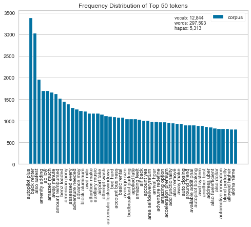

```python
#Let's see the most commong pair of words
from yellowbrick.text import FreqDistVisualizer
from yellowbrick.datasets import load_hobbies
columns=vectorizer.get_feature_names()
visualizer = FreqDistVisualizer(features=columns, orient='v')
visualizer.fit(bow_df)
visualizer.show()
```

```python
Y = df_bof['Ut_R']
X = np.array(df_bof_2.drop(['Description_tokens','Ut_R'], 1))

# We split the dataset into train and test sets
X_train, X_test, y_train, y_test = train_test_split(X, Y, test_size=0.4, random_state=123)

from sklearn.ensemble import RandomForestRegressor
from sklearn.svm import SVR

# Models
lr = LinearRegression()
rfr = RandomForestRegressor()



lr.fit(X_train, y_train)
rfr.fit(X_train, y_train)


print("----------------------Linear Regression Scores----------------------")
print('Training set score:', lr.score(X_train, y_train))
print('\nTest set score:', lr.score(X_test, y_test))

print("----------------------Random Forest Scores----------------------")
print('Training set score:', rfr.score(X_train, y_train))
print('\nTest set score:', rfr.score(X_test, y_test))
```

```
----------------------Linear Regression Scores----------------------
Training set score: 0.950095501773971

Test set score: -2.0534414810993073e+20
----------------------Random Forest Scores----------------------
Training set score: 0.7908610089130393

Test set score: -0.0027424236921256284
```

Obviously not very successful but we will add it into the model on the next stage, results are close to 1 gram

### TD-IDF

Another way of creating dummy variables for the text variable is TD-IDF. The BoW approach rests upon counting the occurrences of the words in the descriptions while we can also include the matrix of the frequencies these words occuren in the sentences and in the corpus

```python
vectorizer = TfidfVectorizer(
    max_df=0.5, min_df=2, ngram_range=(2,2), token_pattern = r'\b[^\d\W]+\b', use_idf=True, norm=u'l2', smooth_idf=True)
#we're using only words that occur no less than 2 times and drop the words that occur in more than half of the document

# applying the vectorizer
X = vectorizer.fit_transform(df['Description_tokens'])
tfidf_df = pd.DataFrame(X.toarray(), columns=vectorizer.get_feature_names())
df_tfidf = pd.concat([tfidf_df, df[['Description_tokens', 'Ut_R']]], axis=1)

# keep in mind that the log base 2 of 1 is 0,
# so a tf-idf score of 0 indicates that the word was present once in that sentence.
tfidf_df.head()
```

|  | aac dual | ab air | ab bluetooth | ab brake | ab break | ab disc | ab driveline | ab emergency | ab front | ab keyless | ... | zone frontcrumple | zone hour | zone rearairbags | zone similar | zoo sd | zoo yosemitenational | zoom need | zoom right | zoom toll | zoom zoom |
| --- | --- | --- | --- | --- | --- | --- | --- | --- | --- | --- | --- | --- | --- | --- | --- | --- | --- | --- | --- | --- | --- |
| 0 | 0.0 | 0.0 | 0.0 | 0.0 | 0.0 | 0.0 | 0.0 | 0.0 | 0.0 | 0.0 | ... | 0.0 | 0.0 | 0.0 | 0.0 | 0.0 | 0.0 | 0.0 | 0.0 | 0.0 | 0.0 |
| 1 | 0.0 | 0.0 | 0.0 | 0.0 | 0.0 | 0.0 | 0.0 | 0.0 | 0.0 | 0.0 | ... | 0.0 | 0.0 | 0.0 | 0.0 | 0.0 | 0.0 | 0.0 | 0.0 | 0.0 | 0.0 |
| 2 | 0.0 | 0.0 | 0.0 | 0.0 | 0.0 | 0.0 | 0.0 | 0.0 | 0.0 | 0.0 | ... | 0.0 | 0.0 | 0.0 | 0.0 | 0.0 | 0.0 | 0.0 | 0.0 | 0.0 | 0.0 |
| 3 | 0.0 | 0.0 | 0.0 | 0.0 | 0.0 | 0.0 | 0.0 | 0.0 | 0.0 | 0.0 | ... | 0.0 | 0.0 | 0.0 | 0.0 | 0.0 | 0.0 | 0.0 | 0.0 | 0.0 | 0.0 |
| 4 | 0.0 | 0.0 | 0.0 | 0.0 | 0.0 | 0.0 | 0.0 | 0.0 | 0.0 | 0.0 | ... | 0.0 | 0.0 | 0.0 | 0.0 | 0.0 | 0.0 | 0.0 | 0.0 | 0.0 | 0.0 |

5 rows × 38918 columns

```python
Y = df_tfidf['Ut_R']
X = np.array(df_tfidf.drop(['Description_tokens','Ut_R'], 1))

# We split the dataset into train and test sets
X_train, X_test, y_train, y_test = train_test_split(X, Y, test_size=0.4, random_state=123)


# Models
lr = LinearRegression()
rfr = RandomForestRegressor()



lr.fit(X_train, y_train)
rfr.fit(X_train, y_train)


print("----------------------Linear Regression Scores----------------------")
print('Training set score:', lr.score(X_train, y_train))
print('\nTest set score:', lr.score(X_test, y_test))

print("----------------------Random Forest Scores----------------------")
print('Training set score:', rfr.score(X_train, y_train))
print('\nTest set score:', rfr.score(X_test, y_test))
```

```
----------------------Linear Regression Scores----------------------
Training set score: -2.8164463498157506

Test set score: -6.2199227359332e+26
----------------------Random Forest Scores----------------------
Training set score: 0.791299677904126

Test set score: 0.05506055870297033
```

#### TF-IDF vectorization

This allows us to create a vector from features and based on it to measure similarity between the descriptions. It creates vectors from nearby words but don't count synonyms

```python
X_train, X_test = train_test_split(df['Description_tokens'], test_size=0.4, random_state=0)

vectorizer = TfidfVectorizer(max_df=0.5, # drop words that occur in more than half the paragraphs
                             min_df=2, # only use words that appear at least twice
                             use_idf=True,#we definitely want to use inverse document frequencies in our weighting
                             norm=u'l2', #Applies a correction factor so that longer paragraphs and shorter paragraphs get treated equally
                             smooth_idf=True #Adds 1 to all document frequencies, as if an extra document existed that used every word once.  Prevents divide-by-zero errors
                            )


#Applying the vectorizer
df_tfidf=vectorizer.fit_transform(df['Description_tokens'])
print("Number of features: %d" % df_tfidf.get_shape()[1])

#splitting into training and test sets
X_train_tfidf, X_test_tfidf= train_test_split(df_tfidf, test_size=0.4, random_state=0)

#Reshapes the vectorizer output into something people can read
X_train_tfidf_csr = X_train_tfidf.tocsr()

#number of paragraphs
n = X_train_tfidf_csr.shape[0]
#A list of dictionaries, one per paragraph
tfidf_bypara = [{} for _ in range(0,n)]
#List of features
terms = vectorizer.get_feature_names()
#for each paragraph, lists the feature words and their tf-idf scores
for i, j in zip(*X_train_tfidf_csr.nonzero()):
    tfidf_bypara[i][terms[j]] = X_train_tfidf_csr[i, j]

#Keep in mind that the log base 2 of 1 is 0, so a tf-idf score of 0 indicates that the word was present once in that sentence.
print('Original sentence:', df['Description_tokens'][5])
print('Tf_idf vector:', tfidf_bypara[5])
```

```
Number of features: 8408
Original sentence: great gas efficient family sunny san diego surprisingly spacious back seat folded extra trunk space sleeping area perfect lift hatch enjoy san diegos beautiful sunset always able tight parking space usb input iphones aux input android
Tf_idf vector: {'audiobluetooth': 0.29584286117495256, '28': 0.2215234865629537, 'interface': 0.21667597118901413, 'seeking': 0.2614672409516017, '23': 0.21238374532128976, 'carplay': 0.15816073398929767, 'apple': 0.13632230155630665, 'crossover': 0.20853256567757442, '31': 0.2094589352709815, 'tint…
```

#### Latent Semantic Analysis

```python
from sklearn.decomposition import TruncatedSVD
from sklearn.pipeline import make_pipeline
from sklearn.preprocessing import Normalizer

#Our SVD data reducer.  We are going to reduce the feature space from 1379 to 130.
svd= TruncatedSVD(130)
lsa = make_pipeline(svd, Normalizer(copy=False))
# Run SVD on the training data, then project the training data.
X_train_lsa = lsa.fit_transform(X_train_tfidf)

variance_explained=svd.explained_variance_ratio_
total_variance = variance_explained.sum()
print("Percent variance captured by all components:",total_variance*100)

#Looking at what sorts of paragraphs our solution considers similar, for the first five identified topics
paras_by_component=pd.DataFrame(X_train_lsa,index=X_train)
for i in range(5):
    print('-------COMPONENT {}:'.format(i))
    print(paras_by_component.loc[:,i].sort_values(ascending=False)[0:5])
    print("-------------------------------------------------------------")
```

```
Percent variance captured by all components: 34.22361690049173
-------COMPONENT 0:
Description_tokens
try brand new black black leather seater luxury lt looking hotel try airbnb following link get reward httpswwwairbnbcommanageyourspace19983099details httpswwwairbnbcomcmateens15currencyusd premium luxury package absolutely luxurious almost brand new seater luxury suv resist fell love black beauty lu…
challenge presented covid19 want reassure everything promote safe secure rental experience touch point interior area exterior handle sanitized clorox wipe pickup also leave colorx wipe use effective march 15th delivery service msp airport place suspended notice pick place also meet person pickup dro…
looking cruise style brand new luxury suv saving compared traditional rental look 2019 well equipped speedy indulgence providing comfortable ride bell whistle spec 20 turbo engine producing 272 hp awd super handling mode snowcomfortsport sport 2227 mpg premium unleaded gas 5passenger cargo thatll la…
beautiful super clean v6 engine awd4wd traction control navigation system touchscreen info center leather seat sunroof moonroof panoramic roof bluetooth heated seat heated steering wheel heated mirror push button start remote start rear camera rear defroster rear wiper aux jack ipodmp3 usp port ezpa…
unlock anytime going problem time convenient location minute walk north berkeley bart station looking rent take everywhere low mpg easy clean well search explore wine county take go hiking yosemite park eat oyster bodega bay go see beautiful carmel monterey acquarium use everyday need grocery job re…
Name: 0, dtype: float64
-------------------------------------------------------------
-------COMPONENT 1:
Description_tokens
30l i6 engine doubleclutch transmission mdct red leather seat power front seat driver seat memory heated front seat heated leather steering wheel paddle shifter cruise control audio steering wheel control bluetooth harmankardon audio system navigation system top view camera headup display automatic …
model extended version larger trunk space navigation premium sound system backup camera rear air satellite radio ipodmp3 input bluetooth heated rear seat running board third row seat power liftgate dual zone ac quad bucket seat flex fuel mp3 player rear seat audio control keyless entry privacy glass…
brand new 2018 xlt 4x4 great snow black leather interior panoramic sunmoon roof navigation bluetooth remote starter steering wheel heating seat heating auto dual zone climate control driver connect lcd touch screen sync sync connect power liftgate 10way power passenger seat forward sensing system   …
authentic exciting energeticthe 2015 ready whatever life throw way styling performance translated successfully subcompact crossover 4wd house cylinder 180 hp engine 9speed automatic transmission find dedicated parking spot valencia st feature keyless entry keyless start seat foldflat rear seat opena…
mercedesbenz glclass fullsize luxury suv perfect family business travel feature include driver assistance package power 3rd row sunroof navigation rear camera keyless go heated seat wood leather steering wheel keyless entry blind spot assist homelink memory seat package speed transmission automatic …
Name: 1, dtype: float64
-------------------------------------------------------------
-------COMPONENT 2:
Description_tokens
rent great lot room great gas mileage                     0.582007
great get point great gas                                 0.560021
charcoal gray new hub cap tire great great gas mileage    0.552559
perfect get around town great gas mileage                 0.544450
clean easy hatchback get great gas mileage                0.529025
Name: 2, dtype: float64
-------------------------------------------------------------
-------COMPONENT 3:
Description_tokens
```

[output cut: 16 more lines]

```python
Based on components we need to try something else as well
```

### word2vec

word2vec is trains a shallow neural network model in an unsupervised manner for converting words to vectors.

```python
# Load Google's pre-trained Word2Vec model.
model_pretrained = gensim.models.KeyedVectors.load_word2vec_format(
    'https://s3.amazonaws.com/dl4j-distribution/GoogleNews-vectors-negative300.bin.gz', binary=True)
```

```python
word2vec_arr = np.zeros((df.shape[0],300))

for i, sentence in enumerate(df['Description_tokens']):
  try:
    word2vec_arr[i,:] = np.mean([model_pretrained[lemma] for lemma in sentence], axis=0)
  except KeyError:
    word2vec_arr[i,:] = np.full((1,300), np.nan)
    continue

word2vec_arr = pd.DataFrame(word2vec_arr)
df_wv = pd.concat([df[["Ut_R", "Description_tokens"]],word2vec_arr], axis=1)
df_wv = df_wv.fillna(0)

print("Shape of the dataset: {}".format(df_wv.shape))
df_wv.head(10)
```

```
Shape of the dataset: (3912, 302)
```

|  | Ut_R | Description_tokens | 0 | 1 | 2 | 3 | 4 | 5 | 6 | 7 | ... | 290 | 291 | 292 | 293 | 294 | 295 | 296 | 297 | 298 | 299 |
| --- | --- | --- | --- | --- | --- | --- | --- | --- | --- | --- | --- | --- | --- | --- | --- | --- | --- | --- | --- | --- | --- |
| 0 | 0.155556 | fantastic 2018 fully loaded feature sleek enou... | 0.0 | 0.0 | 0.0 | 0.0 | 0.0 | 0.0 | 0.0 | 0.0 | ... | 0.0 | 0.0 | 0.0 | 0.0 | 0.0 | 0.0 | 0.0 | 0.0 | 0.0 | 0.0 |
| 1 | 0.027778 | reliable inexpensive safe safe front sideairba... | 0.0 | 0.0 | 0.0 | 0.0 | 0.0 | 0.0 | 0.0 | 0.0 | ... | 0.0 | 0.0 | 0.0 | 0.0 | 0.0 | 0.0 | 0.0 | 0.0 | 0.0 | 0.0 |
| 2 | 0.086207 | excellent gas mileage save 10 every day used m... | 0.0 | 0.0 | 0.0 | 0.0 | 0.0 | 0.0 | 0.0 | 0.0 | ... | 0.0 | 0.0 | 0.0 | 0.0 | 0.0 | 0.0 | 0.0 | 0.0 | 0.0 | 0.0 |
| 3 | 0.031818 | please note sometimes accommodate last minute ... | 0.0 | 0.0 | 0.0 | 0.0 | 0.0 | 0.0 | 0.0 | 0.0 | ... | 0.0 | 0.0 | 0.0 | 0.0 | 0.0 | 0.0 | 0.0 | 0.0 | 0.0 | 0.0 |
| 4 | 0.095238 | handsome midsize suv spacious interior people ... | 0.0 | 0.0 | 0.0 | 0.0 | 0.0 | 0.0 | 0.0 | 0.0 | ... | 0.0 | 0.0 | 0.0 | 0.0 | 0.0 | 0.0 | 0.0 | 0.0 | 0.0 | 0.0 |
| 5 | 0.166667 | great gas efficient family sunny san diego sur... | 0.0 | 0.0 | 0.0 | 0.0 | 0.0 | 0.0 | 0.0 | 0.0 | ... | 0.0 | 0.0 | 0.0 | 0.0 | 0.0 | 0.0 | 0.0 | 0.0 | 0.0 | 0.0 |
| 6 | 0.675743 | welcome smooth ride iii wont win racing award ... | 0.0 | 0.0 | 0.0 | 0.0 | 0.0 | 0.0 | 0.0 | 0.0 | ... | 0.0 | 0.0 | 0.0 | 0.0 | 0.0 | 0.0 | 0.0 | 0.0 | 0.0 | 0.0 |
| 7 | 0.320106 | hey crazy right still rent thing differently a... | 0.0 | 0.0 | 0.0 | 0.0 | 0.0 | 0.0 | 0.0 | 0.0 | ... | 0.0 | 0.0 | 0.0 | 0.0 | 0.0 | 0.0 | 0.0 | 0.0 | 0.0 | 0.0 |
| 8 | 0.651557 | apology im able deliverpickup time location nu... | 0.0 | 0.0 | 0.0 | 0.0 | 0.0 | 0.0 | 0.0 | 0.0 | ... | 0.0 | 0.0 | 0.0 | 0.0 | 0.0 | 0.0 | 0.0 | 0.0 | 0.0 | 0.0 |
| 9 | 0.115942 | equipped sirius radio speaker audio system cd ... | 0.0 | 0.0 | 0.0 | 0.0 | 0.0 | 0.0 | 0.0 | 0.0 | ... | 0.0 | 0.0 | 0.0 | 0.0 | 0.0 | 0.0 | 0.0 | 0.0 | 0.0 | 0.0 |

10 rows × 302 columns

```python
#Let's use this array in the model
```

# BUILD THE REGRESSION MODEL

```python
#Convert text variables into dummies
df = pd.concat([df,pd.get_dummies(df.Type, prefix="Type", drop_first=True)], axis=1)
df = pd.concat([df,pd.get_dummies(df.Color, prefix="Color", drop_first=True)], axis=1)
df = pd.concat([df,pd.get_dummies(df.Transmission, prefix="Trans", drop_first=True)], axis=1)
df = pd.concat([df,pd.get_dummies(df['Fuel Type'], prefix="Fuel", drop_first=True)], axis=1)
df = pd.concat([df,pd.get_dummies(df.Make, prefix="Make", drop_first=True)], axis=1)
df = pd.concat([df,pd.get_dummies(df.cluster_label, prefix="cluster", drop_first=True)], axis=1)
```

```python
dummy_column_names = list(pd.get_dummies(df.Type, prefix="Type", drop_first=True).columns)
dummy_column_names = dummy_column_names + list(pd.get_dummies(df.Color, prefix="Color", drop_first=True).columns)
dummy_column_names = dummy_column_names + list(pd.get_dummies(df.Transmission, prefix="Trans", drop_first=True).columns)
dummy_column_names = dummy_column_names + list(pd.get_dummies(df['Fuel Type'], prefix="Fuel", drop_first=True).columns)
dummy_column_names = dummy_column_names + list(pd.get_dummies(df['Make'], prefix="Make", drop_first=True).columns)
dummy_column_names = dummy_column_names + list(pd.get_dummies(df['cluster_label'], prefix="cluster", drop_first=True).columns)
```